# Facial attractiveness

Alyson Norman, Andy Wills

## Before you start…

Before starting this exercise, you should have completed **all** the Absolute Beginners’ workshop exercises. If not, take a look at those exercises before continuing. Each section below also indicates which of the earlier worksheets are relevant.

## Getting the data into R

**Relevant worksheet:** Intro to RStudio

You’ll be provided with a single CSV file containing both your data, and that of your classmates. Open a project on RStudio Server for this analysis, create a script file, and upload your CSV to your project.

**Plymouth University students**: Create/open your project named `psyc414`; within that create a script file called `face-attract.R`. Enter all commands into that script and run them from there.

## Exploring your data

### Load

**Relevant worksheet:** Exploring data

Load the *tidyverse* package, and load your data.

```r
# Load tidyverse package
library(tidyverse)
# Load data into 'att'
att <- read_csv("faceattract.csv")
```

### Inspect

Look at the data by clicking on it in the *Environment* tab in RStudio. Each row is one person’s rating for one face. Here’s what each of the columns in the data set contain:

| Column | Description | Values |
| --- | --- | --- |
| StudentID | The participant’s Student Reference Number |  |
| TrialNum | Trial number | 0 - 99 |
| Stimulus | Face shown on this trial. Each face has a unique number that identifies it. | 1 - 100 |
| Rating | The facial attractiveness rating for this face, for this participant | 1 - 10, higher numbers = more attractive |

This is a large data set, with about 250 people rating each of 100 faces for attractiveness; so about 25,000 ratings in total. R is great for analysing large data sets easily and without error.

### How much do faces differ in attractiveness?

**Relevant worksheets:** Group Differences, Exploring data

To look at differences in facial attractiveness, we can look at the average (mean) rating each face received, i.e. the average across the hundreds of people who rated it. To do this, we use the `group_by` and `summarise` commands you learned in the *Group Differences* worksheet.

```r
# Calculate mean attractiveness, per face; place into 'av.att'
av.att <- att %>% group_by(Stimulus) %>% summarise(mean = mean(Rating))
```

As before, you can safely ignore the “ungrouping” message that you receive.

You can look at these averages by clicking on `av.att` in the *Environment* tab in RStudio. You should be able to notice that some faces score higher than others, on average. However, it’s pretty hard to get your head around a long list of numbers like this, so next we’re going to draw a graph. This *visualization* will help us more easily comprehend our data.

A *density plot* is a good choice for this kind of data. We covered density plots in the *Group Differences* worksheet, and we can use the same commands here.

```r
# Display density plot of attractiveness ratings
av.att %>% ggplot(aes(mean)) + geom_density(aes(y = ..scaled..))
```

The density plot the above command gives you is OK, but it could be better. First, let’s fix the fact that the x-axis doesn’t cover the full range of the rating scale. Our rating scale goes from 1 to 10. To force R to use that full 1 to 10 range, we use the `xlim` (short for “x-axis limits”) command, like this:

```r
# Display above density plot, with x-axis forced to range from 1 to 10.
av.att %>% ggplot(aes(mean)) + geom_density(aes(y=..scaled..)) + xlim(1, 10)
```

Better…but it would be better still if the axes had more meaningful labels. Use the `xlab` and `ylab` commands you learned in the *Exploring Data* worksheet to add meaningful labels. If you get it right, your graph should look something like this (without the words “example plot”, of course):

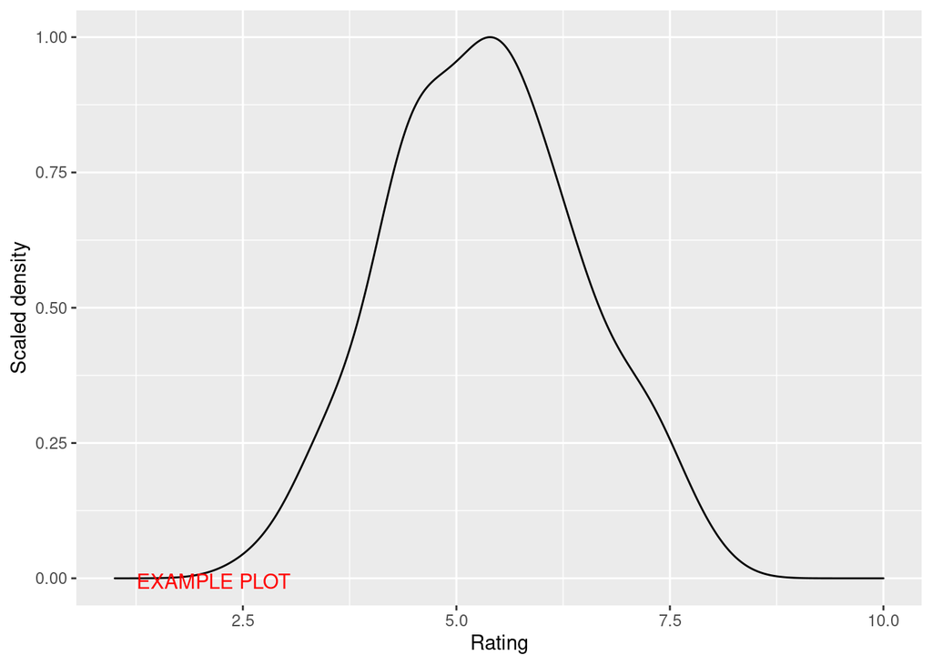

**Use RStudio to export your graph as an Image, and upload it to your lab book.**

### How much do ratings for a face differ?

**Relevant worksheets:** Group Differences, Exploring data

For any given face, does everyone give about the same attractiveness rating? Or, do some people rate it as attractive, while other people rate it as unattractive?

One way we could look at this is to calculate the *standard deviation* of the attractiveness ratings for each face. As we covered in the *Group Differences* worksheet, *standard deviation* is a number that basically represents how far, on average, people are from the mean. We calculate the standard deviation of the face ratings pretty much the same way we calculated the means, just using the command `sd` instead of `mean`:

```r
# Calculate standard deviation of ratings by face; record into 'sd.att'
sd.att <- att %>% group_by(Stimulus) %>% summarise(sd = sd(Rating))
```

We can then look at these standard deviations by clicking on `sd.att` in the *Environment* tab in RStudio. However, like with the mean attractiveness, it’s hard to get a clear sense of what this large table of data is telling us. We can make things clearer, but it’ll take a couple of steps. The first step is to use the *inter-quartile range*, rather than the *standard deviation*.

#### Explaining inter-quartile range

*Inter-quartile range* is a measure that’s somewhat similar to the *standard deviation*, but some people find it easier to interpret once they’ve got their heads around the concept.

To explain *inter-quartile range*, we need to first explain the concepts of the *lower quartile* and the *upper quartile*. These two ideas are related to the idea of a *median*, which you covered in *Exploring Data*. To recap, if you put a set of numbers in order, then the median is the middle number. In other words, it divides the ordered data exactly in half. Half of the data is smaller than the median and half of the data is larger than the median.

The *lower quartile* (LQ) is similar to the median, except that a quarter of the data is smaller than the lower quartile, and three-quarters of the data is larger. Correspondingly, three-quarters of the data is smaller than the *upper quartile* (UQ), and a quarter of it is larger.

So, for a particular face, the median attractiveness rating might be 4 with a LQ of 3 and an UQ of 5. The *inter quartile range* is the difference between the UQ and the LQ. So, in this example the inter-quartile range is 5 - 3 = 2. The *inter-quartile range* contains the middle 50% of the ordered data.

The larger the *inter-quartile range*, the more people’s ratings of the same face differ.

#### Calculating inter-quartile range

Calculating inter-quartile range in R works much the same way as calculating a mean, median, or standard deviation. The command is `IQR`, which we use like this:

```r
# Calculate inter-quartile range of ratings by face; record into 'iqr.att'
iqr.att <- att %>% group_by(Stimulus) %>% summarise(IQR = IQR(Rating))
```

We can then look at these inter-quartile ranges by clicking on `iqr.att` in the *Environment* tab in RStudio. While this might be a bit of an improvement, it’s still a very long table of numbers. So, as the final exercise in this worksheet, calculate the mean inter-quartile range from your `iqr.att` data frame, using the `summarise` and `mean` commands. If you’ve done it right, your output will look something like this (the exact number will be different):

```
# A tibble: 1 × 1
  `mean(IQR)`
        <dbl>
1        2.00
```

**Enter your mean inter-quartile range into your lab book.**

This material is distributed under a [Creative Commons](https://creativecommons.org/) licence. CC-BY-SA 4.0.